# 多因子返修主板診斷預警系統 pipeline Demo

```python
import os
from pyspark import SparkContext, SparkConf, HiveContext
from pyspark.sql import SQLContext
os.environ['PYSPARK_PYTHON'] = '/opt/anaconda2-4.0.0/bin/python'
conf = SparkConf()
conf.set('spark.master', 'yarn-client')
conf.set('spark.app.name', 'pipeline_test_andy')
conf.set('spark.yarn.queue', 'default')
conf.set('spark.executor.instances', '8')
conf.set('spark.executor.memory', '10g')
conf.set('spark.executor.cores', '5')
conf.set('spark.driver.memory', '10g')
conf.set('spark.driver.maxResultSize', '10g')
conf.set('spark.jars', 'hdfs://ha/user/mlb/tmp/tony/sqljdbc4.jar')

sc = SparkContext(conf=conf)

sqlContext = SQLContext(sc)
hc = HiveContext(sc)
```

```python
sc.addFile('mllib.py')
```

```python
import timeit
```

```python
time from IPython.display import Image
```

```
CPU times: user 0 ns, sys: 0 ns, total: 0 ns
Wall time: 37.9 µs
```

[figure not shown]

```python
Image(filename='pipeline_overview.png')
```

### import mllib 模組

取名mllib純粹巧合

```python
import mllib
```

```python
reload(mllib)
```

```
<module 'mllib' from 'mllib.pyc'>
```

## Step 1 建立DataLoader

```python
Image(filename='step1.png')
```

[output not shown]

```python
time loader = mllib.DataLoader(model='N71', station='FCT')
```

```
CPU times: user 0 ns, sys: 0 ns, total: 0 ns
Wall time: 241 µs
```

### 載入 (14天前) testlog 資料與 (14天前到當日) mlb fatp 綁定資料

這部分是可以再調整

```python
logDf, fatpDf = loader.load_X(hiveContext=hc, shift=1)
```

```python
logDf.show()
```

```
+----------------+-----------+-------------------+--------------------+------------+-------+---------+----+--------------------+-------------+-----+-------+
|   serial_number|test_result|    test_start_time|             version|        line|machine|test_type|slot|               items|         hour|model|station|
+----------------+-----------+-------------------+--------------------+------------+-------+---------+----+--------------------+-------------+-----+-------+
|F3X540414BQG2KMA|       FAIL|2016-04-11 10:07:40|7.27c_Maserati_MP...| D03-3FRF-01|     12|   Normal|   2|Map(adc_BIST_amux...|2016-04-11_10|  N71|    FCT|
|F3X54220SW8GKFCB|       PASS|2016-04-11 09:35:08|7.27c_Maserati_MP...|D03-3FTFB-01|      3|   Normal|   1|Map(adc_BIST_amux...|2016-04-11_09|  N71|    FCT|
|F3X544426FGG2KNB|       PASS|2016-04-11 12:22:37|7.27c_Maserati_MP...| D03-3FRF-01|     11|   Normal|   2|Map(adc_BIST_amux...|2016-04-11_12|  N71|    FCT|
|F3X544445EPG2KNB|       PASS|2016-04-11 12:42:52|7.27c_Maserati_MP...| D03-3FRF-01|      5|   Normal|   3|Map(adc_BIST_amux...|2016-04-11_12|  N71|    FCT|
|F3X54561KSJG2KMC|       PASS|2016-04-11 09:59:10|7.27c_Maserati_MP...| D03-3FRF-01|     11|   Normal|   2|Map(adc_BIST_amux...|2016-04-11_09|  N71|    FCT|
|F3X54653H2XG2KMC|       PASS|2016-04-11 20:36:22|7.27c_Maserati_MP...|F07-3FCRB-01|      4|   Normal|   4|Map(adc_BIST_amux...|2016-04-11_20|  N71|    FCT|
|F3X54821YU5G2KND|       PASS|2016-04-11 10:44:21|7.27c_Maserati_MP...| D03-3FRF-01|     10|   Normal|   4|Map(adc_BIST_amux...|2016-04-11_10|  N71|    FCT|
|F3X551212DVG2KMC|       PASS|2016-04-11 12:24:40|7.27c_Maserati_MP...| D03-3FRF-01|      6|   Normal|   1|Map(adc_BIST_amux...|2016-04-11_12|  N71|    FCT|
|F3X60430XXUG2KMC|       PASS|2016-04-11 14:39:06|7.27c_Maserati_MP...|F07-4FCRB-02|      3|   Normal|   4|Map(adc_BIST_amux...|2016-04-11_14|  N71|    FCT|
|F3X60621MF1G2KNE|       PASS|2016-04-11 23:05:18|7.27c_Maserati_MP...|F07-3FCRB-01|      4|   Normal|   1|Map(adc_BIST_amux...|2016-04-11_23|  N71|    FCT|
|F3X6116032AG2KNE|       PASS|2016-04-11 10:04:03|7.27c_Maserati_MP...|F07-3FCRB-01|     10|   Normal|   3|Map(adc_BIST_amux...|2016-04-11_10|  N71|    FCT|
|F3X6123071UGKF9F|       PASS|2016-04-11 09:54:03|7.27c_Maserati_MP...|F07-3FCRT-03|      3|   Normal|   1|Map(adc_BIST_amux...|2016-04-11_09|  N71|    FCT|
|F3X61260GLEG2KME|       PASS|2016-04-11 17:06:54|7.27c_Maserati_MP...|F07-3FCRB-01|     12|   Normal|   3|Map(adc_BIST_amux...|2016-04-11_17|  N71|    FCT|
|F3X613601L0GKF9F|       FAIL|2016-04-11 21:23:38|7.27c_Maserati_MP...|F07-3FCRB-01|      6|   Normal|   4|Map(adc_BIST_amux...|2016-04-11_21|  N71|    FCT|
|F3X6142023SGKF9F|       PASS|2016-04-11 10:37:55|7.27c_Maserati_MP...|F07-3FCRB-01|     12|   Normal|   3|Map(adc_BIST_amux...|2016-04-11_10|  N71|    FCT|
|F3X6142125XG2KME|       PASS|2016-04-11 09:12:28|7.27c_Maserati_MP...|F07-3FCRT-03|      9|   Normal|   3|Map(adc_BIST_amux...|2016-04-11_09|  N71|    FCT|
|F3X614304N0G2KME|       PASS|2016-04-11 21:10:07|7.27c_Maserati_MP...|F07-4FCRB-02|      6|   Normal|   4|Map(adc_BIST_amux...|2016-04-11_21|  N71|    FCT|
|F3X614306WJG2KME|       PASS|2016-04-11 12:19:03|7.27c_Maserati_MP...| D03-3FRF-01|      1|   Normal|   2|Map(adc_BIST_amux...|2016-04-11_12|  N71|    FCT|
|F3X61431QXAG2KME|       PASS|2016-04-11 10:58:13|7.27c_Maserati_MP...|F07-4FCRB-02|      4|   Normal|   4|Map(adc_BIST_amux...|2016-04-11_10|  N71|    FCT|
|F3X614403EPG2KNF|       PASS|2016-04-11 09:23:13|7.27c_Maserati_MP...|F07-3FCRT-03|      2|   Normal|   4|Map(adc_BIST_amux...|2016-04-11_09|  N71|    FCT|
+----------------+-----------+-------------------+--------------------+------------+-------+---------+----+--------------------+-------------+-----+-------+
only showing top 20 rows
```

```python
fatpDf.show()
```

```
+------------+----------------+-------------------+-------+----------+-----+
|      wip_no|          mlb_sn|          scan_time|dislink|       day|model|
+------------+----------------+-------------------+-------+----------+-----+
|DNPRL08HGRXW|F3X61620QU9GKFCF|2016-04-18 09:17:19|      0|2016-04-18|  N71|
|DNPRL05BGRXW|F3X616209XFGKFCF|2016-04-18 09:23:00|      0|2016-04-18|  N71|
|DNPRL0KZGRYC|F3Y61640877G2KNF|2016-04-18 09:23:55|      0|2016-04-18|  N71|
|DNPRL0EFGRY9|F3Y616400VQG2KNF|2016-04-18 09:25:12|      0|2016-04-18|  N71|
|F17RKDG0GRY9|F3X61550F5XG2KNF|2016-04-18 09:19:24|      0|2016-04-18|  N71|
|F17RL3D6GRY5|F3Y6156146GG2KME|2016-04-18 09:21:10|      0|2016-04-18|  N71|
|F17RL2Q3GRY8|F3Y616504FDG2KME|2016-04-18 09:26:06|      0|2016-04-18|  N71|
|F17RKJB8GRY7|F3Y61560J8BG2KME|2016-04-18 09:29:09|      0|2016-04-18|  N71|
|FK1RL081GRY7|F3X616208CCG2KME|2016-04-18 09:17:17|      0|2016-04-18|  N71|
|FK1RL0HQGRY6|F3Y61640K8PG2KME|2016-04-18 09:21:39|      0|2016-04-18|  N71|
|FK1RL0DLGRY6|F3Y61560FKNG2KME|2016-04-18 09:23:06|      0|2016-04-18|  N71|
|FK1RL0ADGRY7|F3Y616409VRG2KME|2016-04-18 09:25:23|      0|2016-04-18|  N71|
|FK1RL1XXGRY8|F3Y61560EGNG2KME|2016-04-18 09:26:30|      0|2016-04-18|  N71|
|F17RL0F1GRY9|F3X61550HUNG2KNF|2016-04-18 11:45:10|      0|2016-04-18|  N71|
|F17RL2G2GRY5|F3Y61560DKLG2KME|2016-04-18 11:51:13|      0|2016-04-18|  N71|
|F17RL0K2GRYD|F3X61561688G2KNF|2016-04-18 11:59:37|      0|2016-04-18|  N71|
|DNPRL0Q8GRY9|F3Y61640707G2KNF|2016-04-18 12:42:05|      0|2016-04-18|  N71|
|DNPRL09LGRYC|F3Y6164037QG2KNF|2016-04-18 12:42:46|      0|2016-04-18|  N71|
|DNPRL185GRXW|F3X616308NXGKFCF|2016-04-18 12:43:01|      0|2016-04-18|  N71|
|F17RL0HQGRYD|F3X61570834G2KNF|2016-04-18 12:35:11|      0|2016-04-18|  N71|
+------------+----------------+-------------------+-------+----------+-----+
only showing top 20 rows
```

### 載入 SQL Server RPC返修資料

rpc返修資料由於資料量不大, 因此沒有限定時間條件做篩選, 基本上全抓

```python
rpcDf = loader.load_y(sparkContext=sc, connect='jdbc')
```

```python
rpcDf
```

```
DataFrame[serial_number: string, check_in_code: string, symptom: string, fail_location: string, ever_tfb_check_in: int, day: string]
```

## Step 2. 建立MatrixCreator

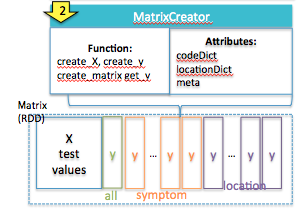

```python
Image(filename='step2.png')
```

```python
matrixCreator = mllib.MatrixCreator(logDf, fatpDf, rpcDf)
```

### 建立預測模型使用之X矩陣

```python
X = matrixCreator.create_X()
```

```python
X
```

```
DataFrame[serial_number: string, items: map<string,string>]
```

```python
matrixCreator.meta.show()
```

```
+----------------+--------------------+------------+-------+----+-------------+
|   serial_number|             version|        line|machine|slot|         hour|
+----------------+--------------------+------------+-------+----+-------------+
|F3X54120DGBGKFCA|7.27c_Maserati_MP...| D03-3FRF-01|      1|   3|2016-04-11_17|
|F3X54227M6DG2KNB|7.27c_Maserati_MP...| D03-3FRF-01|      6|   3|2016-04-11_10|
|F3X54352PVZG2KNB|7.27c_Maserati_MP...| D03-3FRF-01|      2|   3|2016-04-11_12|
|F3X54451RTNG2KNB|7.27c_Maserati_MP...| D03-3FRF-01|      2|   3|2016-04-11_12|
|F3X54623YSWG2KND|7.27c_Maserati_MP...| D03-3FRF-01|     12|   1|2016-04-11_12|
|F3X54830CQYG2KND|7.27c_Maserati_MP...| D03-3FRF-01|     11|   2|2016-04-11_11|
|F3X54840S8WG2KMC|7.27c_Maserati_MP...| D03-3FRF-01|      1|   4|2016-04-11_16|
|F3X54923VASG2KMC|7.27c_Maserati_MP...| D03-3FRF-01|      5|   3|2016-04-11_11|
|F3X54950G69G2KMC|7.27c_Maserati_MP...| D03-3FRF-01|      6|   1|2016-04-11_10|
|F3X61350B77G2KME|7.27c_Maserati_MP...|F07-3FCRB-01|      9|   3|2016-04-11_10|
|F3X613510REG2KME|7.27c_Maserati_MP...|F07-3FCRB-01|     11|   4|2016-04-11_11|
|F3X614404UEG2KME|7.27c_Maserati_MP...| D03-3FRF-01|     12|   2|2016-04-11_09|
|F3X61440SXYG2KME|7.27c_Maserati_MP...|F07-4FCRB-07|      4|   2|2016-04-11_22|
|F3X61450BD5G2KME|7.27c_Maserati_MP...|F07-3FCRT-03|      7|   1|2016-04-11_14|
|F3X61450WS7G2KME|7.27c_Maserati_MP...|F07-4FCRT-07|      5|   2|2016-04-11_16|
|F3X6145152AG2KME|7.27c_Maserati_MP...|D03-3FTFB-01|     12|   2|2016-04-11_11|
|F3X614519CNG2KME|7.27c_Maserati_MP...|F07-3FCRB-01|      4|   3|2016-04-11_21|
|F3X61451NLJG2KME|7.27c_Maserati_MP...| D03-3FRF-01|      1|   4|2016-04-11_14|
|F3X615305L7G2KLF|7.27c_Maserati_MP...|F07-3FCRT-03|      3|   4|2016-04-11_17|
|F3X61530H0FG2KME|7.27c_Maserati_MP...|F07-4FCRB-02|      8|   1|2016-04-11_22|
+----------------+--------------------+------------+-------+----+-------------+
only showing top 20 rows
```

### 建立綜合矩陣matirx

```python
rpcDf.show()
```

```
+----------------+---------------+--------------------+-------------+-----------------+----------+
|   serial_number|  check_in_code|             symptom|fail_location|ever_tfb_check_in|       day|
+----------------+---------------+--------------------+-------------+-----------------+----------+
|F3Y604605LKGH6KA|     TECMC19542|LTE Band 20 V4 In...|   U_LBPAD_RF|                0|2016-02-03|
|F3Y60530AWAG35WC|   AGECFBUR3347|Earthbound Earthb...|      U_BB_RF|                0|2016-02-27|
|F3Y61050DHSG2KMD|        MSC1MF0| Can't test fail-FCT|        U4500|                0|2016-03-15|
|F3Y61220P9XG35WD|AGERAC-COSMATIC|        CRB進板外觀目檢無不良|        J4700|                0|2016-03-22|
|F3Y605504U6G35WC|   AGECFBUR2874|      Can't power on|     U_PMU_RF|                2|2016-02-22|
|F3Y605504U6G35WC|   AGECFBUR2874|      Can't power on|        R2210|                2|2016-02-18|
|F3Y605504U6G35WC|   AGECFBUR2874|      Can't power on|        C2210|                2|2016-02-18|
|F3Y605504U6G35WC|   AGECFBUR2874|      Can't power on|     UTRIP_RF|                2|2016-02-19|
|F3Y61060AMDGJYDA|  TESCFFACTB105|Microphone1Test_L...|        U2300|                0|2016-03-14|
|F3Y61050253G35WC|   AGECFBUR3458|wakeonstockholm_m...|        U0600|                0|2016-03-10|
|F3Y61340JKJG35WD|   AGECFBUR3458|wakeonstockholm_m...|        U0600|                0|2016-03-31|
|F3Y61160309GKL0D|     AGERACFDFU|       DFU Test Fail|     U5200_RF|                0|2016-03-23|
|F3Y61050253G35WC|   AGECFBUR3458|wakeonstockholm_m...|        U3000|                0|2016-03-17|
|F3Y604601M6GP3VA|   TESLAC-RUNV5|              驗證臨時使用|       FL4602|                0|2016-02-03|
|F3Y604601M6GP3VA|   TESLAC-RUNV5|              驗證臨時使用|        J4700|                0|2016-02-26|
|F3Y6114013BG360B|    AGECFRAT124|tcTxPower tLTE:ba...|     U5411_RF|                0|2016-03-22|
|F3Y609701SFGH6KA|   TESCFBUR5444|reboot Component ...|        R2210|                0|2016-03-18|
|F3X61050KXLG2KMD|     MSC1MQB123| BB FW Version Check|     J3001_RF|                0|2016-03-17|
|F3Y61122MEUG360B|    AGECFUNIT26|    Pick Camera_Back|        R3234|                0|2016-03-16|
|F3Y60920E0MG35WC|   AGERAC-SHORT|             CRB短路專案|        C2009|                0|2016-03-08|
+----------------+---------------+--------------------+-------------+-----------------+----------+
only showing top 20 rows
```

```python
matrix = matrixCreator.create_matrix(X, rpcDf)
```

```
top 1 symptom: MSCMDL0, count: 56
top 1 fail location: U0600, count: 44
top 2 symptom: MSC1MCC0, count: 35
top 2 fail location: U_VOX_RF, count: 17
top 3 symptom: MSC1MD73, count: 21
top 3 fail location: U3500, count: 11
top 4 symptom: RUNINFACHECKIN01, count: 21
top 4 fail location: U5200_RF, count: 10
```

matrix 也只是一個Spark DataFrame

```python
matrix
```

```
DataFrame[serial_number: string, items: map<string,string>, SN: string, check_in_code: string, symptom: string, fail_location: string, ever_tfb_check_in: int, day: string, y: int, MSCMDL0: int, U0600: int, MSC1MCC0: int, U_VOX_RF: int, MSC1MD73: int, U3500: int, RUNINFACHECKIN01: int, U5200_RF: int]
```

matrix show出來的結果

matrix只是在後面加上y, symptom與locatio的欄位, 每個欄位1代表返修, 0代表沒有返修

```python
matrix.show()
```

```
+----------------+--------------------+----------------+-------------+--------------------+-------------+-----------------+----------+---+-------+-----+--------+--------+--------+-----+----------------+--------+
|   serial_number|               items|              SN|check_in_code|             symptom|fail_location|ever_tfb_check_in|       day|  y|MSCMDL0|U0600|MSC1MCC0|U_VOX_RF|MSC1MD73|U3500|RUNINFACHECKIN01|U5200_RF|
+----------------+--------------------+----------------+-------------+--------------------+-------------+-----------------+----------+---+-------+-----+--------+--------+--------+-----+----------------+--------+
|F3X54120DGBGKFCA|Map(adc_BIST_amux...|            null|         null|                null|         null|             null|      null|  0|      0|    0|       0|       0|       0|    0|               0|       0|
|F3X54227M6DG2KNB|Map(adc_BIST_amux...|            null|         null|                null|         null|             null|      null|  0|      0|    0|       0|       0|       0|    0|               0|       0|
|F3X54352PVZG2KNB|Map(adc_BIST_amux...|            null|         null|                null|         null|             null|      null|  0|      0|    0|       0|       0|       0|    0|               0|       0|
|F3X54451RTNG2KNB|Map(adc_BIST_amux...|            null|         null|                null|         null|             null|      null|  0|      0|    0|       0|       0|       0|    0|               0|       0|
|F3X54623YSWG2KND|Map(adc_BIST_amux...|            null|         null|                null|         null|             null|      null|  0|      0|    0|       0|       0|       0|    0|               0|       0|
|F3X54830CQYG2KND|Map(adc_BIST_amux...|            null|         null|                null|         null|             null|      null|  0|      0|    0|       0|       0|       0|    0|               0|       0|
|F3X54840S8WG2KMC|Map(adc_BIST_amux...|            null|         null|                null|         null|             null|      null|  0|      0|    0|       0|       0|       0|    0|               0|       0|
|F3X54923VASG2KMC|Map(adc_BIST_amux...|            null|         null|                null|         null|             null|      null|  0|      0|    0|       0|       0|       0|    0|               0|       0|
|F3X54950G69G2KMC|Map(adc_BIST_amux...|            null|         null|                null|         null|             null|      null|  0|      0|    0|       0|       0|       0|    0|               0|       0|
|F3X61350B77G2KME|Map(adc_BIST_amux...|            null|         null|                null|         null|             null|      null|  0|      0|    0|       0|       0|       0|    0|               0|       0|
|F3X613510REG2KME|Map(adc_BIST_amux...|            null|         null|                null|         null|             null|      null|  0|      0|    0|       0|       0|       0|    0|               0|       0|
|F3X614404UEG2KME|Map(adc_BIST_amux...|F3X614404UEG2KME|   MASCFQC109|Compass_1_Test_NMS_Z|        U3000|                2|2016-04-19|  1|      0|    0|       0|       0|       0|    0|               0|       0|
|F3X614404UEG2KME|Map(adc_BIST_amux...|F3X614404UEG2KME|   MASCFQC109|Compass_1_Test_NMS_Z|        J3100|                2|2016-04-20|  1|      0|    0|       0|       0|       0|    0|               0|       0|
|F3X61440SXYG2KME|Map(adc_BIST_amux...|            null|         null|                null|         null|             null|      null|  0|      0|    0|       0|       0|       0|    0|               0|       0|
|F3X61450BD5G2KME|Map(adc_BIST_amux...|            null|         null|                null|         null|             null|      null|  0|      0|    0|       0|       0|       0|    0|               0|       0|
|F3X61450WS7G2KME|Map(adc_BIST_amux...|            null|         null|                null|         null|             null|      null|  0|      0|    0|       0|       0|       0|    0|               0|       0|
|F3X6145152AG2KME|Map(adc_BIST_amux...|            null|         null|                null|         null|             null|      null|  0|      0|    0|       0|       0|       0|    0|               0|       0|
|F3X614519CNG2KME|Map(adc_BIST_amux...|            null|         null|                null|         null|             null|      null|  0|      0|    0|       0|       0|       0|    0|               0|       0|
|F3X61451NLJG2KME|Map(adc_BIST_amux...|            null|         null|                null|         null|             null|      null|  0|      0|    0|       0|       0|       0|    0|               0|       0|
|F3X615305L7G2KLF|Map(adc_BIST_amux...|            null|         null|                null|         null|             null|      null|  0|      0|    0|       0|       0|       0|    0|               0|       0|
+----------------+--------------------+----------------+-------------+--------------------+-------------+-----------------+----------+---+-------+-----+--------+--------+--------+-----+----------------+--------+
only showing top 20 rows
```

這個矩陣的相關資訊存放在matrixCreator的meta裡頭, 不過他是一個Spark DataFrame, RDD, 並沒有action

```python
matrixCreator.codeDict
```

```
{u'MSC1MCC0': 35, u'MSC1MD73': 21, u'MSCMDL0': 56, u'RUNINFACHECKIN01': 21}
```

```python
matrixCreator.locationDict
```

```
{u'U0600': 44, u'U3500': 11, u'U5200_RF': 10, u'U_VOX_RF': 17}
```

## Step 3. 資料前置處理 - 欄位分析

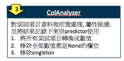

```python
Image(filename='step3.png')
```

```python
colAnalyzer = mllib.ColAnalyzer()
```

```python
colInfo = colAnalyzer.analyze_column(matrixCreator=matrixCreator, sparkContext=sc)
```

```
There are 90 columns being removed
the number is correct
```

## Step 4-5-6. 建立模型

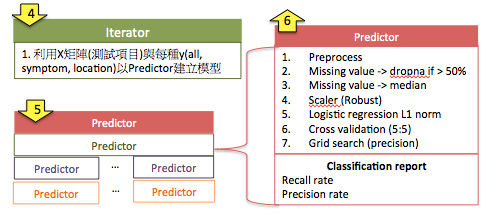

```python
Image(filename='step456.png')
```

```python
iterator = mllib.Iterator(matrix=matrix, matrixCreator=matrixCreator, sparkContext=sc, colInfo=colInfo)
```

```python
modelsDict = iterator.modeling(sampling=True)
```

```
no target specified
MSC1MCC0
RUNINFACHECKIN01
MSC1MD73
MSCMDL0
U_VOX_RF
U3500
U0600
U5200_RF
```

```python
modelsDict
```

```
{'all': {'model': GridSearchCV(cv=None, error_score='raise',
         estimator=Pipeline(steps=[('impute', Imputer(axis=1, copy=True, missing_values='NaN', strategy='median', verbose=0)), ('scaler', RobustScaler(copy=True, with_centering=True, with_scaling=True)), ('clf', LogisticRegression(C=1.0, class_weight='balanced', dual=False,
            fit_intercept=True, intercept_scaling=1, max_iter=100,
            multi_class='ovr', n_jobs=1, penalty='l2', random_state=None,
            solver='liblinear', tol=0.0001, verbose=0, warm_start=False))]),
         fit_params={}, iid=True, n_jobs=1,
         param_grid={'clf__tol': (1, 0.1, 0.01, 0.001, 0.0001), 'clf__penalty': ('l1', 'l2'), 'clf__C': (10, 5, 1, 0.1, 0.01, 0.001, 0.0001)},
         pre_dispatch='2*n_jobs', refit=True, scoring='precision', verbose=0),
  'prediction_report': '             precision    recall  f1-score   support\n\n          0       0.99      0.91      0.95      3200\n          1       0.24      0.73      0.36       129\n\navg / total       0.96      0.90      0.92      3329\n'},
 'code': {u'MSC1MCC0': {'model': GridSearchCV(cv=None, error_score='raise',
          estimator=Pipeline(steps=[('impute', Imputer(axis=1, copy=True, missing_values='NaN', strategy='median', verbose=0)), ('scaler', RobustScaler(copy=True, with_centering=True, with_scaling=True)), ('clf', LogisticRegression(C=1.0, class_weight='balanced', dual=False,
             fit_intercept=True, intercept_scaling=1, max_iter=100,
             multi_class='ovr', n_jobs=1, penalty='l2', random_state=None,
             solver='liblinear', tol=0.0001, verbose=0, warm_start=False))]),
          fit_params={}, iid=True, n_jobs=1,
          param_grid={'clf__tol': (1, 0.1, 0.01, 0.001, 0.0001), 'clf__penalty': ('l1', 'l2'), 'clf__C': (10, 5, 1, 0.1, 0.01, 0.001, 0.0001)},
          pre_dispatch='2*n_jobs', refit=True, scoring='precision', verbose=0),
   'prediction_report': '             precision    recall  f1-score   support\n\n          0       1.00      0.99      1.00      3318\n          1       0.23      0.64      0.33        11\n\navg / total       1.00      0.99      0.99      3329\n'},
  u'MSC1MD73': {'model': GridSearchCV(cv=None, error_score='raise',
          estimator=Pipeline(steps=[('impute', Imputer(axis=1, copy=True, missing_values='NaN', strategy='median', verbose=0)), ('scaler', RobustScaler(copy=True, with_centering=True, with_scaling=True)), ('clf', LogisticRegression(C=1.0, class_weight='balanced', dual=False,
             fit_intercept=True, intercept_scaling=1, max_iter=100,
             multi_class='ovr', n_jobs=1, penalty='l2', random_state=None,
             solver='liblinear', tol=0.0001, verbose=0, warm_start=False))]),
          fit_params={}, iid=True, n_jobs=1,
          param_grid={'clf__tol': (1, 0.1, 0.01, 0.001, 0.0001), 'clf__penalty': ('l1', 'l2'), 'clf__C': (10, 5, 1, 0.1, 0.01, 0.001, 0.0001)},
          pre_dispatch='2*n_jobs', refit=True, scoring='precision', verbose=0),
   'prediction_report': '             precision    recall  f1-score   support\n\n          0       1.00      1.00      1.00      3324\n          1       0.20      0.20      0.20         5\n\navg / total       1.00      1.00      1.00      3329\n'},
  u'MSCMDL0': {'model': GridSearchCV(cv=None, error_score='raise',
          estimator=Pipeline(steps=[('impute', Imputer(axis=1, copy=True, missing_values='NaN', strategy='median', verbose=0)), ('scaler', RobustScaler(copy=True, with_centering=True, with_scaling=True)), ('clf', LogisticRegression(C=1.0, class_weight='balanced', dual=False,
             fit_intercept=True, intercept_scaling=1, max_iter=100,
             multi_class='ovr', n_jobs=1, penalty='l2', random_state=None,
             solver='liblinear', tol=0.0001, verbose=0, warm_start=False))]),
          fit_params={}, iid=True, n_jobs=1,
          param_grid={'clf__tol': (1, 0.1, 0.01, 0.001, 0.0001), 'clf__penalty': ('l1', 'l2'), 'clf__C': (10, 5, 1, 0.1, 0.01, 0.001, 0.0001)},
          pre_dispatch='2*n_jobs', refit=True, scoring='precision', verbose=0),
   'prediction_report': '             precision    recall  f1-score   support\n\n          0       1.00      0.90      0.95      3312\n          1       0.03      0.65      0.06        17\n\navg / total       0.99      0.90      0.94      3329\n'},
  u'RUNINFACHECKIN01': {'model': GridSearchCV(cv=None, error_score='raise',
          estimator=Pipeline(steps=[('impute', Imputer(axis=1, copy=True, missing_values='NaN', strategy='median', verbose=0)), ('scaler', RobustScaler(copy=True, with_centering=True, with_scaling=True)), ('clf', LogisticRegression(C=1.0, class_weight='balanced', dual=False,
             fit_intercept=True, intercept_scaling=1, max_iter=100,
             multi_class='ovr', n_jobs=1, penalty='l2', random_state=None,
```

[output cut: 98 more lines]

```
             multi_class='ovr', n_jobs=1, penalty='l2', random_state=None,
             solver='liblinear', tol=0.0001, verbose=0, warm_start=False))]),
          fit_params={}, iid=True, n_jobs=1,
          param_grid={'clf__tol': (1, 0.1, 0.01, 0.001, 0.0001), 'clf__penalty': ('l1', 'l2'), 'clf__C': (10, 5, 1, 0.1, 0.01, 0.001, 0.0001)},
          pre_dispatch='2*n_jobs', refit=True, scoring='precision', verbose=0),
   'prediction_report': '             precision    recall  f1-score   support\n\n          0       1.00      1.00      1.00      3325\n          1       0.00      0.00      0.00         4\n\navg / total       1.00      1.00      1.00      3329\n'},
  u'U_VOX_RF': {'model': GridSearchCV(cv=None, error_score='raise',
          estimator=Pipeline(steps=[('impute', Imputer(axis=1, copy=True, missing_values='NaN', strategy='median', verbose=0)), ('scaler', RobustScaler(copy=True, with_centering=True, with_scaling=True)), ('clf', LogisticRegression(C=1.0, class_weight='balanced', dual=False,
             fit_intercept=True, intercept_scaling=1, max_iter=100,
             multi_class='ovr', n_jobs=1, penalty='l2', random_state=None,
             solver='liblinear', tol=0.0001, verbose=0, warm_start=False))]),
          fit_params={}, iid=True, n_jobs=1,
          param_grid={'clf__tol': (1, 0.1, 0.01, 0.001, 0.0001), 'clf__penalty': ('l1', 'l2'), 'clf__C': (10, 5, 1, 0.1, 0.01, 0.001, 0.0001)},
          pre_dispatch='2*n_jobs', refit=True, scoring='precision', verbose=0),
   'prediction_report': '             precision    recall  f1-score   support\n\n          0       1.00      1.00      1.00      3323\n          1       0.00      0.00      0.00         6\n\navg / total       1.00      0.99      1.00      3329\n'}}}
```

```python
for key in modelsDict.keys():
    print 'model: {}'.format(key)
    if key == 'all':
        print 'Precision rate during testing: {}'.format(modelsDict[key]['model'].best_score_)
        print 'Best parameters: {}'.format(modelsDict[key]['model'].best_params_)
        print '\n'
        print modelsDict[key]['prediction_report']
        print '\n'
    else:
        for subkey in modelsDict[key].keys():
            print 'code:{}'.format(subkey)
            print 'precision rate during testing: {}'.format(modelsDict[key][subkey]['model'].best_score_)
            print 'Best parameters: {}'.format(modelsDict[key][subkey]['model'].best_params_)
            print modelsDict[key][subkey]['prediction_report']
```

```
model: all
Precision rate during testing: 0.274291279385
Best parameters: {'clf__C': 1, 'clf__penalty': 'l1', 'clf__tol': 0.0001}


             precision    recall  f1-score   support

          0       0.99      0.91      0.95      3200
          1       0.24      0.73      0.36       129

avg / total       0.96      0.90      0.92      3329



model: code
code:MSC1MD73
precision rate during testing: 0.537044189806
Best parameters: {'clf__C': 10, 'clf__penalty': 'l1', 'clf__tol': 0.01}
             precision    recall  f1-score   support

          0       1.00      1.00      1.00      3324
          1       0.20      0.20      0.20         5

avg / total       1.00      1.00      1.00      3329

code:MSCMDL0
precision rate during testing: 0.174936557695
Best parameters: {'clf__C': 1, 'clf__penalty': 'l1', 'clf__tol': 0.001}
             precision    recall  f1-score   support

          0       1.00      0.90      0.95      3312
          1       0.03      0.65      0.06        17

avg / total       0.99      0.90      0.94      3329

code:U5200_RF
precision rate during testing: 0.0
Best parameters: {'clf__C': 10, 'clf__penalty': 'l1', 'clf__tol': 1}
             precision    recall  f1-score   support

```

[output cut: 120 more lines]

```

          0       1.00      0.99      1.00      3318
          1       0.23      0.64      0.33        11

avg / total       1.00      0.99      0.99      3329

code:U3500
precision rate during testing: 0.00980013480866
Best parameters: {'clf__C': 5, 'clf__penalty': 'l2', 'clf__tol': 0.001}
             precision    recall  f1-score   support

          0       1.00      0.96      0.98      3325
          1       0.02      0.75      0.04         4

avg / total       1.00      0.96      0.98      3329
```

```python
for key in modelsDict.keys():
    print key
```

```
all
code
location
```

```python
model = modelsDict['all']['model']
```

```python
model.best_params_
```

```
{'clf__C': 1, 'clf__penalty': 'l1', 'clf__tol': 0.0001}
```

```python
totalNum = logDf.count()
```

```python
returnNum = matrix[matrix['y'] == 1].count()
```

```python
totalNum
```

```
118749
```

```python
returnNum
```

```
404
```

# Summary

```python
loader.parameters
```

```
{'end_date_fatp': '2016-04-30',
 'end_time_log': '2016-04-11_23',
 'model': 'N71',
 'start_date_fatp': '2016-04-10',
 'start_time_log': '2016-04-10_00',
 'station': 'FCT'}
```

```python
best = model.best_estimator_
```

```python
coef = best.named_steps['clf'].coef_
```

```python
len(coef[0])
```

```
691
```

```python
len(colInfo['preprocess']['final'])
```

```
691
```

```python
import matplotlib.pyplot as plt
```

```python
%matplotlib inline
```

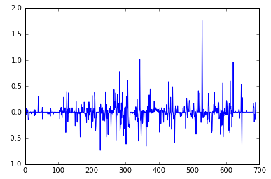

```python
plt.plot(coef[0])
```

```python
coef[0][coef[0] > 80]
```

```
array([], dtype=float64)
```

```python
itemindex = np.where(coef[0] > 10)
```

[output not shown]

```python
from operator import itemgetter
```

```python
import pandas as pd
```

```python
test = pd.Series(colInfo['preprocess']['final'])
```

```python
itemindex[0]
```

```python
test[itemindex[0]]
```

```python
from bokeh.plotting import figure, show, output_file, vplot
from bokeh.io import output_notebook
from bokeh.plotting import figure, show
```

```python
output_notebook()
```

```python
import numpy as np
```

```python
x = [1, 2, 3, 4, 5]
y = [6, 7, 8, 9, 10]
```

```python
p = figure(title="simple line example", x_axis_label = 'x')
```

```python
p.line(x, y)
```